# Chromosome compation - simple 3-state model

Marek Gierlinski

## Data

In our data we distinguish four states, marked by colour: blue, brown, pink, red. For the purpose of the model we merge blue and brown together into one state. Here is the result of the experiment from 38 cells.

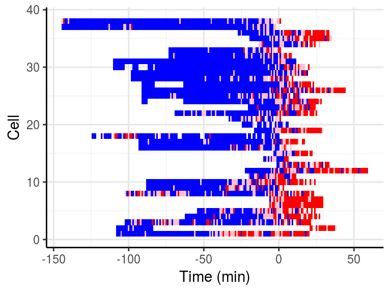

The next figure shows the proportions of each colour as a function of time. The curves are smoothed with a running mean over the window of 5 time points.

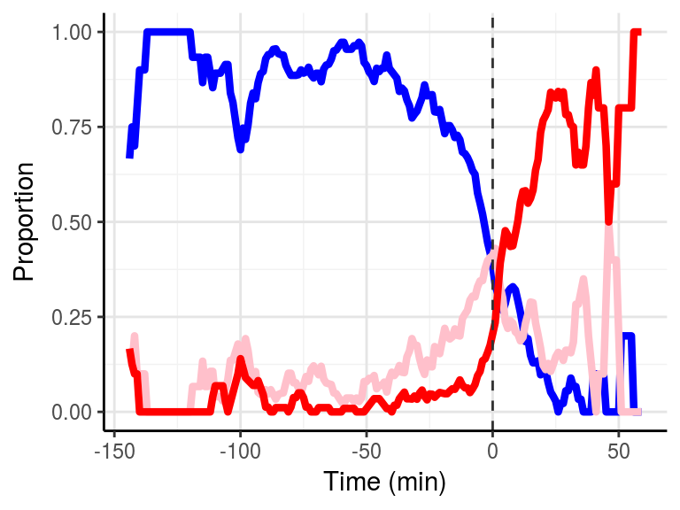

## Model

The model is going to be very simple. It consists of three states and only forward transitions are allowed. This way we can reduce the number of free parameters.

### States

- blue/brown (BB)
- pink (P)
- red (R)

### Transition rates

| Transition | $t < t_1$ | $t_1 < t < t_1 + \Delta t$ | $t > t_1 + \Delta t$ |
| --- | --- | --- | --- |
| BB->P | 0 | $r_1$ | $r_1$ |
| P->R | 0 | 0 | $r_2$ |

### Details

The algorithm is simple: for each cell we generate two transitions (BB->P and P->R) according to the table above. The transition times are random numbers with exponential distribution, $P(t) = 1 - e^{-rt}$. The exponential distribution describes a process with constant probability of the event happening.

From transition times we know the history of the cell, its state as a function of time. This process is repeated for 1000 cells and then the colour propotions are found at each time point. An example of the simulation result is shown here.

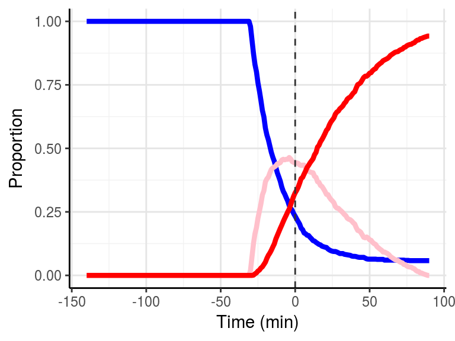